# Welcome to Kawaguchi Lab

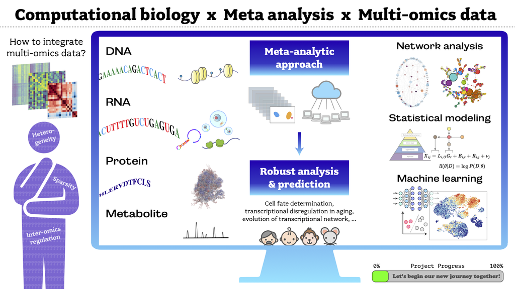

Computational biology lab at Graduate School of Pharmaceutical Sciences, the University of Tokyo and iPS Cell Research and Application (CiRA), Kyoto University, towards understanding a ubiquitous mechanism to regulate intra- and inter-cellular variations.

News

We are currently recruiting graduate students. If you are interested in joining our lab, please feel free to contact me via [contact form](https://docs.google.com/forms/d/e/1FAIpQLSc_ni86GMInVAlfgEQm0EbtNpZHDLms2TVTllK7vvE-WcH7NQ/viewform).  
We also welcome research interns (international/domestic as CiRA research intern students and domestic Ph.D researcher as NCGT intern) and JSPS research fellows.  
Below is the official information regarding entrance examinations for enrollment in the 2027 academic year:  
・Graduate school of Pharmaceutical Sciences, the University of Tokyo: [Admission information](https://israr.f.u-tokyo.ac.jp/en/admission/examination.html) (An information session will be held on May 9th.)

[figure not shown]

## History

- 2026.04.01 Updated.
- 2026.02.02 Updated.
- 2025.09.07 Updated.
- 2025.08.14 Updated.
- 2025.02.17 Updated.
- 2024.12.04 Updated.
- 2024.07.04 Updated.
- 2024.03.26 Updated.
- 2024.02.13 CiRA internship application is open.
- 2023.11.13 Updated.
- 2023.10.30 Updated.
- 2023.08.30 Updated.
- 2023.07.31 Updated.
- 2023.07.13 Updated.
- 2023.04.20 Updated.
- 2023.03.08 Updated.
- 2022.12.22 Updated.
- 2022.09.22 Launched this website.